# **Optimism, information criteria and cross-validation**

# Optimism

The definition of **Optimism** is the expected difference of the test error and training error
$$\begin{aligned}
\mathrm{Opt} &= \mathbb{E}(\mathrm{MSE}_{\mathrm{Te}}) - \mathbb{E}(\mathrm{MSE}_{\mathrm{Tr}})
\end{aligned}$$

For the fixed-X setting, we have
$$\mathrm{OptF} = \mathbb{E}\left[ \frac{1}{n}\sum_{i=1}^{n}( y^*_i - \hat{f}(x_i))^2 - \frac{1}{n}\sum_{i=1}^{n}( y_i - \hat{f}(x_i))^2 \right]$$
Optimism can be also expressed as
$$\mathrm{OptF} = \frac{2}{n}\sum_{i=1}^{n}\mathbb{C}\mathrm{ov}(y_i,\hat{f}(x_i))$$

So the higher the correlation between $y_i$ and its fitted value $\hat{f}(x_i)$, the greater the optimism.

Optimism is an interesting and important concept because an estimate of $\widehat{\mathrm{OptF}}$ of $\mathrm{OptF}$ leads to an estimate of prediction error $\mathrm{ErrF} = \mathbb{E}(\mathrm{MSE}_{\mathrm{Te}}) = \mathbb{E}(\mathrm{MSE}_{\mathrm{Tr}}) + \mathrm{OptF}$:
$$\begin{aligned}
\widehat{\mathrm{ErrF}} &= \mathrm{MSE}_{\mathrm{Tr}} + \widehat{\mathrm{OptF}}\\
\end{aligned}$$

For the linear model, it can be shown that
$$\mathrm{OptF} = \frac{2\sigma^2 p}{n}$$

The above formula assumes that $\sigma^2$ is known, which is not realistic. In practice, we can plug-in its estimate
$$\hat{\sigma}^2= \frac{\mathrm{RSS}}{n-p}= \frac{\sum_{i=1}^{n}( y_i - \hat{f}(x_i))^2}{n-p}$$
where $\mathrm{RSS} = n \mathrm{MSE}_{\mathrm{Tr}}$ is the **residual sum of squares**. This gives
$$\begin{aligned}
\widehat{\mathrm{ErrF}} &= \mathrm{MSE}_{\mathrm{Tr}} + \frac{2 \hat{\sigma}^2 p}{n}\\
\end{aligned}$$
This estimator is also known as **Mallows’ Cp**
$$\begin{aligned}
\mathrm{Cp} &= \mathrm{MSE}_{\mathrm{Tr}} + \frac{2 \hat{\sigma}^2 p}{n}\\
\end{aligned}$$

We illustrate the optimism with the yesterday-tomorrow data. In the last lecture we have computed $\mathrm{MSE}_{\mathrm{Tr}}$ and $\mathrm{ErrF}$.

```r
rm(list=ls())
library(readr)
df <- read_table2("http://azzalini.stat.unipd.it/Book-DM/yesterday.dat")[-31,]
train <- data.frame(x=df$x, y=df$y.yesterday)
# compute MSE.tr
n <- nrow(train)
ds = 1:15
ps = ds + 1
x = seq(.5,3,length=30)
fun <- function(d) if (d==0) lm(y~1, train) else lm(y~poly(x,degree=d), train)
fits <- lapply(ds, fun)
MSEs.tr <- unlist( lapply(fits, deviance) )/n
# compute ErrF
sigmatrue = 0.01
ftrue <- c(0.4342,0.4780,0.5072,0.5258,0.5369,0.5426,0.5447,0.5444,0.5425,0.5397,0.5364,0.5329,0.5294,0.5260,0.5229,0.5200,0.5174,0.5151,0.5131,0.5113,0.5097,0.5083,0.5071,0.5061,0.5052,0.5044,0.5037,0.5032,0.5027,0.5023)
x = seq(.5,3,length=30)
Bias2s = sapply(ps, function(p)
  mean( ( ftrue - fitted(lm(ftrue ~ poly(x,degree=(p-1)))) )^2 )
)
Vars = ps*(sigmatrue^2)/n
ErrFs = Bias2s + Vars + sigmatrue^2
```

Now we compare these values to $\widehat{\mathrm{ErrF}} = \mathrm{MSE}_{\mathrm{Tr}} + \frac{2\sigma^2 p}{n}$ knowing that the true $\sigma=0.01$:

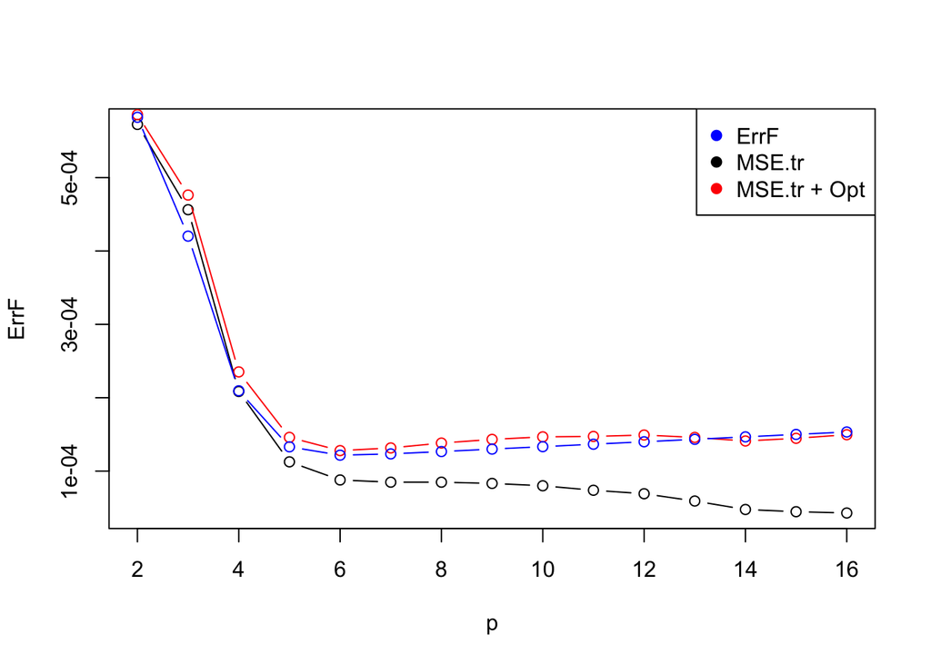

```r
hatErrFs = MSEs.tr + (2*sigmatrue^2*ps)/n
plot(ps, MSEs.tr, type="b", xlab="p", ylab="ErrF")
lines(ps, hatErrFs, type="b", col=2)
lines(ps, ErrFs, type="b", col=4)
legend("topright",c("ErrF","MSE.tr","MSE.tr + Opt"), col=c(4,1,2), pch=19)
```

```r
ps[which.min(hatErrFs)]
```

```
[1] 6
```

Now we compute $\widehat{\mathrm{ErrF}} = \mathrm{MSE}_{\mathrm{Tr}} + \frac{2\hat{\sigma}^2 p}{n}$

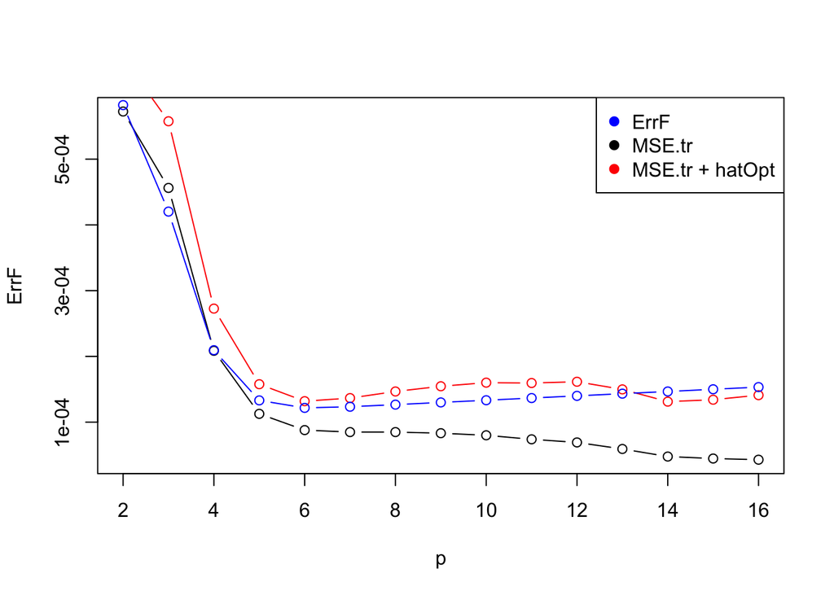

```r
hatsigma2 = (n*MSEs.tr)/(n-ps)
Cps = MSEs.tr + (2*hatsigma2*ps)/n
plot(ps, MSEs.tr, type="b", xlab="p", ylab="ErrF")
lines(ps, Cps, type="b", col=2)
lines(ps, ErrFs, type="b", col=4)
legend("topright",c("ErrF","MSE.tr","MSE.tr + hatOpt"), col=c(4,1,2), pch=19)
```

```r
ps[which.min(Cps)]
```

```
[1] 14
```

This is because of the different estimates $\hat{\sigma}^2$ for $\sigma^2$:

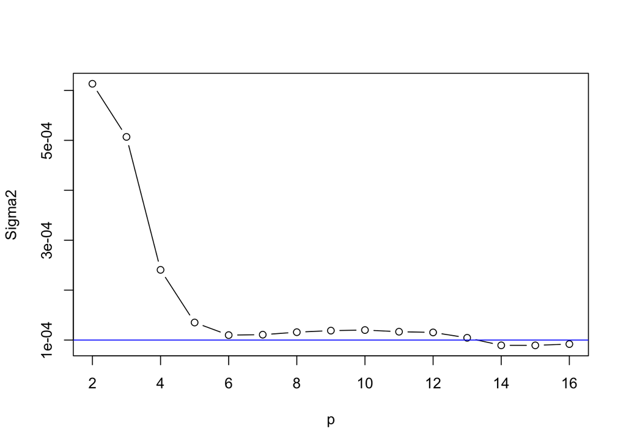

```r
plot(ps, hatsigma2, type="b", xlab="p", ylab="Sigma2")
abline(h=sigmatrue^2, col=4)
```

# Information criteria

The AIC criterion is defined for a large class of models fit by maximum likelihood. In the case of the linear model with Gaussian errors, maximum likelihood and least squares are the same thing. In this case AIC is given by
$$\begin{aligned}
\mathrm{AIC} &= -2 \cdot \mathrm{likelihood}(\hat{\beta},\hat{\sigma}^2) + 2p\\
\end{aligned}$$

where for the linear model $-2 \cdot \mathrm{likelihood}(\hat{\beta},\hat{\sigma}^2) = n \log(\mathrm{MSE}_{\mathrm{Tr}})$ Hence for least squares models, Cp and AIC are proportional to each other, and the lowest Cp corresponds to the lowest AIC.

BIC is derived from a Bayesian point of view, but ends up looking similar to Cp and AIC as well. For the least squares model with $p$ predictors, the BIC is given by

$$\begin{aligned}
\mathrm{BIC} &= -2 \cdot \mathrm{likelihood}(\hat{\beta},\hat{\sigma}^2) + \log(n)p\\
\end{aligned}$$

Like Cp, the BIC will tend to take on a small value for a model with a low test error, and so generally we select the model that has the lowest BIC value.

Notice that BIC replaces the $2p$ used by AIC with a $\log(n)p$ term, where $n$ is the number of observations. Since $\log(n) > 2$ for any $n > 7$, the BIC statistic generally places a heavier penalty on models with many variables, and hence results in the selection of smaller models than AIC.

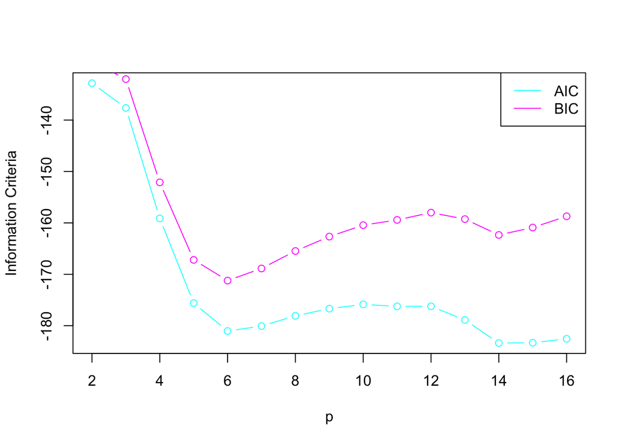

```r
AICs <- unlist( lapply(fits, AIC) )
BICs <- unlist( lapply(fits, BIC) )
plot(ps, AICs, type="b", col=5, ylab="Information Criteria", xlab="p")
lines(ps, BICs, type="b", col=6)
legend("topright",c("AIC","BIC"), col=c(5,6), lty=1)
```

```r
ps[which.min(AICs)]
```

```
[1] 14
```

```r
ps[which.min(BICs)]
```

```
[1] 6
```

# Cross-validation

As noticed earlier, training an algorithm and evaluating its statistical performance on the same data yields an overoptimistic result. **Cross-validation** (CV) was raised to fix this issue, starting from the remark that testing the output of the algorithm on new data would yield a good estimate $\widehat{\mathrm{Err}}$ of the expected test error $\mathbb{E}(\mathrm{MSE}_{\mathrm{Te}})$

In most real applications, only a limited amount of data is available, which leads to the idea of **splitting the data**: Part of data (the training set) is used for training the algorithm, and the remaining data (the validation set) are used for evaluating the performance of the algorithm. The validation set can play the role of new data as long as data are i.i.d.. A single data split yields a **validation estimate** of the expected test error, and averaging over several splits yields a **cross-validation** estimate
$$\widehat{\mathbb{E}(\mathrm{MSE}_{\mathrm{Te}})}$$

The major interest of CV lies in the universality of the data splitting heuristics. Therefore, CV is a non-parametric method which can be applied to any algorithm in any framework. This universality is not shared by e.g. Cp, which is specific to linear regression.

## Validation set approach

A simple approach is to randomly divide the $n$ observations into two parts: a training set and a **validation** or hold-out set.

- [ISLR Fig. 5.1](http://www-bcf.usc.edu/~gareth/ISL/Chapter5/5.1.pdf)

The model is fitted on the training set $T \subset \{1,\ldots,n\}$, and the fitted model $\hat{f}^{-V}$ is used to predict the responses for the observations in the validation set $V = \{1,\ldots,n\} \setminus T$, providing an estimate of the expected test error
$$\widehat{\mathrm{Err}} = \frac{1}{\# V} \sum_{i \in V} (y_i - \hat{f}^{-V}(x_i))^2$$

This scheme reduces the sample size used for fitting the model, but this is not a problem when $n$ is very large. If $n$ is not very large, however, the validation estimate of the test error can be highly variable, depending on precisely which observations are included in the training set and which observations are included in the validation set.

## Cross-validation

One way of partially overcoming this arbitrariness is to split the data into equal parts $V_1,\ldots,V_K$.

- [ISLR Fig. 5.5](http://www-bcf.usc.edu/~gareth/ISL/Chapter5/5.5.pdf)

In **$K$-fold cross-validation** we use observations $i\notin V_k$ for training the model and $i \in V_k$ for evaluating it:

$$\frac{1}{\# V_k} \sum_{i \in V_k} (y_i - \hat{f}^{-V_k}(x_i))^2$$
and finally we take the average to estimate the expected test error:

$$\widehat{\mathrm{Err}} = \frac{1}{K} \sum_{k=1}^{K}\left[ \frac{1}{\# V_k} \sum_{i \in V_k} (y_i - \hat{f}^{-V_k}(x_i))^2 \right]$$

By hand

```r
# K-fold CV
d = 3
K = 5
set.seed(123)
# create folds
folds <- sample( rep(1:K,length=n) )
# initialize vector
KCV <- vector()
# loop
for (k in 1:K){
  fit <- lm(y~poly(x,degree=d), train, subset=which(folds!=k))
  x.out <- train$x[which(folds==k)]
  yhat <- predict(fit, newdata=list(x=x.out))
  y.out <- train$y[which(folds==k)]
  KCV[k]<- mean( ( y.out - yhat )^2 )
}
# KCV estimate
mean(KCV)
```

```
[1] 0.0002705619
```

By function

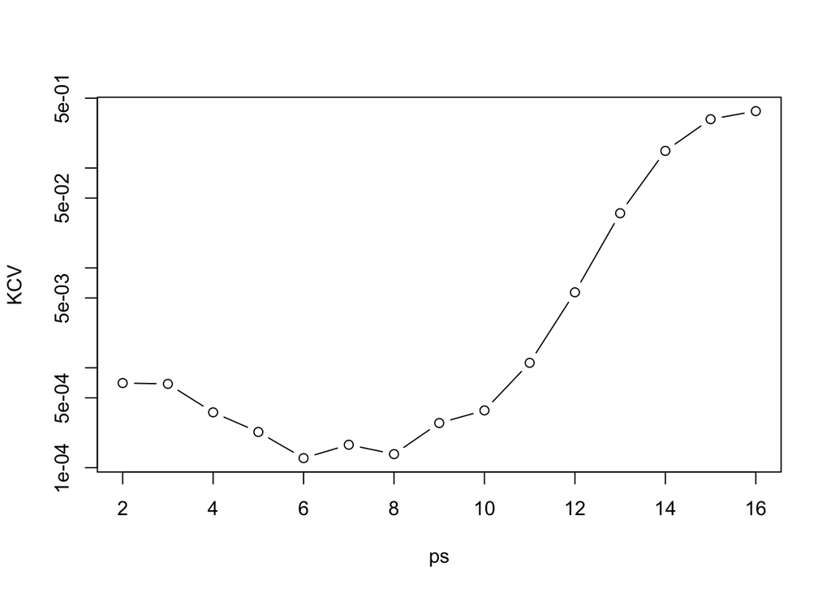

```r
library(boot)
ds = 1:15
ps = ds+1
set.seed(123)
KCV = sapply(ds, function(d)
     cv.glm(train, glm(y~poly(x,degree=d),
     train, family = gaussian), K=K )$delta[1] )
plot(ps, KCV, type="b", log="y")
```

```r
ps[which.min(KCV)]
```

```
[1] 6
```

In **leave-one-out cross validation** (LOOCV), each data point is successively left out from the sample and used for validation.

- [ISLR Fig. 5.3](http://www-bcf.usc.edu/~gareth/ISL/Chapter5/5.3.pdf)

For $i=1,\ldots,n$:

- Hold out the $i$th training observation $(x_i,y_i)$
- Use $n-1$ training observations for training the model $\hat{f}^{-i}$ and the hold-out observation $(x_i,y_i)$ to evaluate it by $(y_i - \hat{f}^{-i}(x_i))^2$
- Finally take the average
  $$\widehat{\mathrm{Err}} = \frac{1}{n} \sum_{i=1}^{n} (y_i - \hat{f}^{-i}(x_i))^2$$

Note that LOOCV is a special case of $K$-fold CV corresponding to $K = n$.

By hand

```r
# LOOCV
oneout <- vector()
# loop
for (i in 1:n){
fit_i <- lm( y~poly(x,degree=d), data=train[-i,])
yhat_i <- predict(fit_i, newdata=data.frame(x=train$x[i]) )
oneout[i] <- ( train$y[i] -  yhat_i )^2
}
# LOOCV estimate
mean(oneout)
```

```
[1] 0.0003439458
```

For the linear model, there is a **shortcut** for computing LOOCV:

$$\frac{1}{n}\sum_{i=1}^{n}\Big( y_i - \hat{f}^{-i}(x_i) \Big)^2 = \frac{1}{n} \sum_{i=1}^{n}\left( \frac{y_i - \hat{f}(x_i)}{1-h_{ii}} \right)^2$$

where $h_{ii}$ is the $i$th diagonal element of the projection (hat) matrix
$$\underset{n\times n}{\mathbf{H}} = \mathbf{X}(\mathbf{X}^\mathsf{T}\mathbf{X})^{-1}\mathbf{X}^\mathsf{T}$$
where $\underset{n\times p}{\mathbf{X}}$ is the design matrix.

By matrix

```r
fit <-  lm(y~poly(x,d), train)
# design matrix
X <- model.matrix(fit)
# hat matrix
H <- X %*% solve(t(X)%*% X) %*% t(X)
# LOOCV estimate
mean(
   ( (train$y - predict(fit)) / (1-diag(H))  )^2
)
```

```
[1] 0.0003439458
```

By function

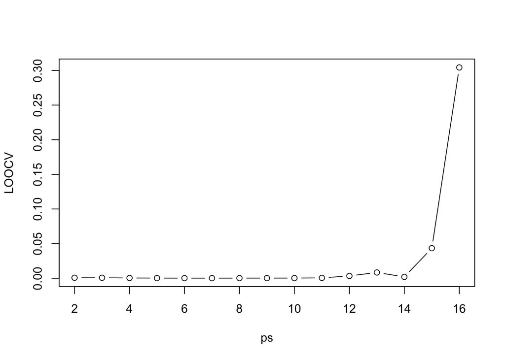

```r
LOOCV = sapply(ds, function(d)
     cv.glm(train, glm(y~poly(x,degree=d),
     train, family = gaussian) )$delta[1] )
plot(ps, LOOCV, type="b")
```

```r
ps[which.min(LOOCV)]
```

```
[1] 7
```

In **generalized cross-validation** we compute

$$\widehat{\mathrm{Err}} =\frac{ \mathrm{MSE}_{\mathrm{Tr}}}{\left(1 - \frac{p}{n}\right)^2}$$
where we approximate each $h_{ii}$ by their average $\frac{1}{n}\sum_{i=1}^{n} h_{ii} = \frac{p}{n}$

By function

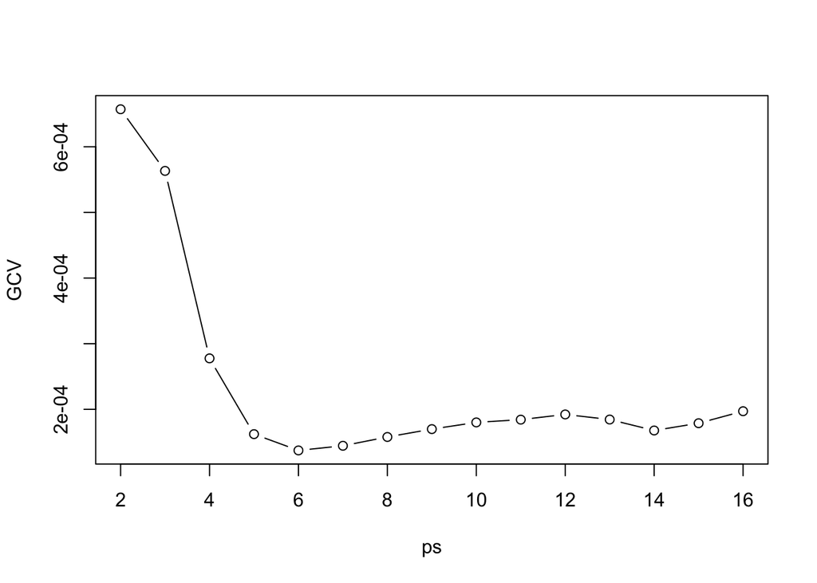

```r
GCV = MSEs.tr/(1-(ps)/n )^2
plot(ps, GCV, type="b")
```

```r
ps[which.min(GCV)]
```

```
[1] 6
```

## Bias-variance trade-off for CV

A common choice for $K$ other than $K = n$ is to choose $K = 5$ or $K = 10$. However, drawing a general conclusion on CV is nearly an impossible task because of the variety of frameworks. Nevertheless, we can still point out that there is a bias-variance trade-off in choosing a CV procedure.

**Bias**

- $K$-fold CV with $K=5$ or 10 gives a biased (upward) estimate of $\mathbb{E}(\mathrm{MSE}_{\mathrm{Te}})$ because it uses less information ($4/5$ or $9/10$ of the observations)
- LOOCV has very low bias (it uses $n-1$ observations)

**Variance**

- Usually, LOOCV has high variance because it is an average of $n$ extremely correlated quantities (because the fits $\hat{f}^{-i}$ and $\hat{f}^{-l}$ are based on $n-2$ common observations), and $K$-fold CV with $K=5$ or 10 has less variance because it is an average of quantities that are less correlated.
  Remember that the variance of the sum of highly correlated quantities is larger than that with midly correlated quantities:
  $$\mathbb{V}\mathrm{ar}(A+B) = \mathbb{V}\mathrm{ar}(A) + \mathbb{V}\mathrm{ar}(B) + 2\mathbb{C}\mathrm{ov}(A,B)$$
- However, in general the variance of different CV methods seems strongly framework-dependent